# Simple linear regression

RMS2 Sem 1, Week 1

RMS2 team

23 October 2020

# What are RMarkdown files?

RMarkdown files (extension .Rmd) let you store in a single document

- text
- code
- output from the code

making it easier to generate reports and share your results with the wider community.

If you were to use R scripts, instead, you could only include code in the file. All the output should then be copied and pasted into a word document to create a report.

This document shows how to structure your solution to each week’s exercises.

Some notes:

- Write bold words by wrapping them with two asterisks or underscores: **bold** or **bold**
- Write italic words by wrapping them with one asterisk or underscore: *italic* or *italic*
- Titles follow a hierarchical ordering specified by hashtags.

# Exercises

## Question 1

The file name ends with .csv, meaning that the file is in comma separated value form. The function to read a CSV file into R is read_csv.

Load the tidyverse library, required to read the data with read_csv and use data manipulation functions:

```r
library(tidyverse)
```

Read the data into R:

```r
riverview <- read_csv(file = "https://uoepsy.github.io/data/riverview.csv")
```

Check for reading errors by inspecting the first six rows of the data:

```r
head(riverview)
```

```
## # A tibble: 6 x 6
##   education income seniority gender  male party
##       <dbl>  <dbl>     <dbl> <chr>  <dbl> <chr>
## 1         8   37.4         7 male       1 Democrat
## 2         8   26.4         9 female     0 Independent
## 3        10   47.0        14 male       1 Democrat
## 4        10   34.2        16 female     0 Independent
## 5        10   25.5         1 female     0 Republican
## 6        12   46.5        11 female     0 Democrat
```

## Question 2

Density curve and boxplot displaying the marginal distribution of employee incomes:

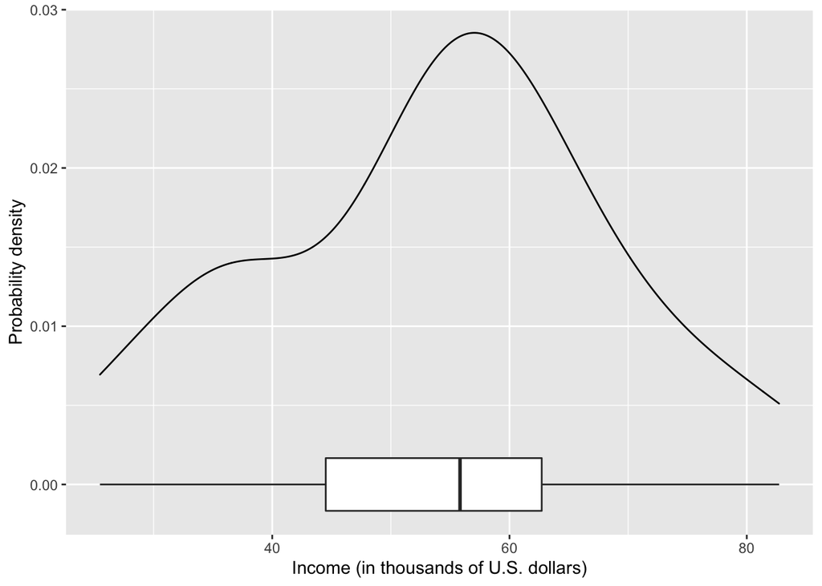

```r
ggplot(data = riverview, aes(x = income)) +
  geom_density() +
  geom_boxplot(width = 1/300) +
  labs(x = "Income (in thousands of U.S. dollars)",
       y = "Probability density")
```

Summary statistics:

```r
riverview %>%
  summarize(
    M = mean(income),
    SD = sd(income)
    )
```

```
## # A tibble: 1 x 2
##       M    SD
##   <dbl> <dbl>
## 1  53.7  14.6
```

The marginal distribution of income is unimodal with a mean of approximately $53,700. There is variation in employees’ salaries (SD = $14,553).

## Question 3

Density curve and boxplot displaying the marginal distribution of years of formal education:

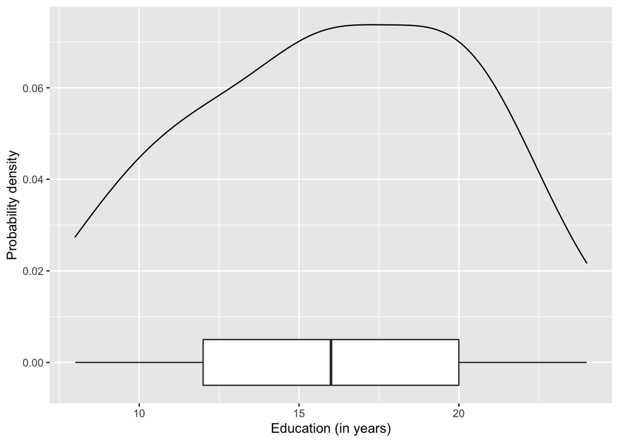

```r
ggplot(data = riverview, aes(x = education)) +
  geom_density() +
  geom_boxplot(width = 1/100) +
  labs(x = "Education (in years)",
       y = "Probability density")
```

Summary statistics:

```r
riverview %>%
  summarize(
    M = mean(education),
    SD = sd(education)
    )
```

```
## # A tibble: 1 x 2
##       M    SD
##   <dbl> <dbl>
## 1    16  4.36
```

The marginal distribution of education is unimodal with a mean of 16 years. There is variation in employees’ level of education (SD = 4.4 years).

## Question 4

Scatterplot displaying the relationship between employees’ education level and income:

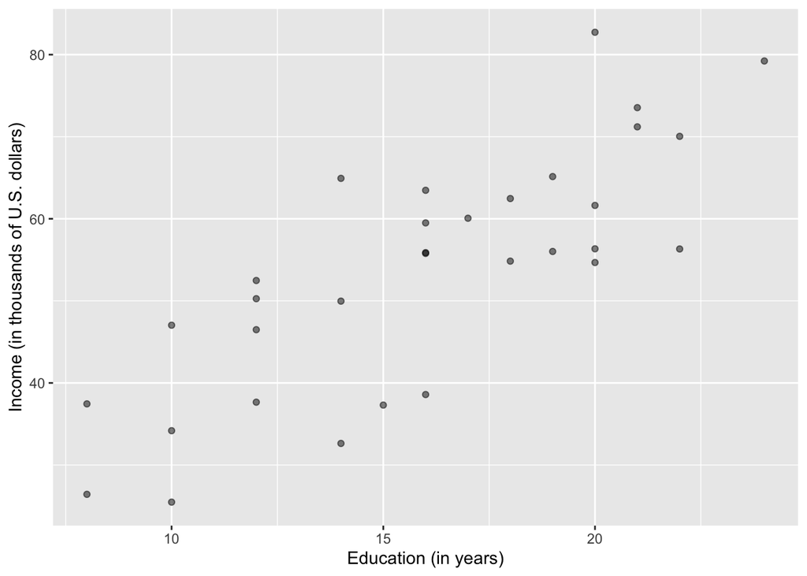

```r
ggplot(data = riverview, aes(x = education, y = income)) +
  geom_point(alpha = 0.5) +
  labs(x = "Education (in years)",
       y = "Income (in thousands of U.S. dollars)")
```

To comment on the strength of the linear association we compute the correlation coefficient:

```r
riverview %>%
  select(education, income) %>%
  cor()
```

```
##           education    income
## education 1.0000000 0.7947847
## income    0.7947847 1.0000000
```

There is a strong positive linear relationship between education level and income for the employees in the sample. High incomes tend to be observed, on average, with more years of formal education. The scatterplot does not highlight any outliers.

## Question 5

Fit a simple linear model having income as response variable and education as predictor. The model also include an intercept term, here it is explicitly mentioned by saying “1 +”, but this is always included by default, so we can also avoid specifying it in the code:

```r
mdl <- lm(income ~ 1 + education, data = riverview)
mdl
```

```
##
## Call:
## lm(formula = income ~ 1 + education, data = riverview)
##
## Coefficients:
## (Intercept)    education
##      11.321        2.651
```

To write maths, wrap it with double dollar signs

$$\widehat{Income} = 11.32 + 2.65 Education$$

## Question 6

```r
mdl
```

```
##
## Call:
## lm(formula = income ~ 1 + education, data = riverview)
##
## Coefficients:
## (Intercept)    education
##      11.321        2.651
```

```r
mdl$coefficients
```

```
## (Intercept)   education
##   11.321379    2.651297
```

```r
coef(mdl)
```

```
## (Intercept)   education
##   11.321379    2.651297
```

```r
coefficients(mdl)
```

```
## (Intercept)   education
##   11.321379    2.651297
```

```r
summary(mdl)
```

```
##
## Call:
## lm(formula = income ~ 1 + education, data = riverview)
##
## Residuals:
##     Min      1Q  Median      3Q     Max
## -15.809  -5.783   2.088   5.127  18.379
##
## Coefficients:
##             Estimate Std. Error t value Pr(>|t|)
## (Intercept)  11.3214     6.1232   1.849   0.0743 .
## education     2.6513     0.3696   7.173 5.56e-08 ***
## ---
## Signif. codes:  0 '***' 0.001 '**' 0.01 '*' 0.05 '.' 0.1 ' ' 1
##
## Residual standard error: 8.978 on 30 degrees of freedom
## Multiple R-squared:  0.6317, Adjusted R-squared:  0.6194
## F-statistic: 51.45 on 1 and 30 DF,  p-value: 5.562e-08
```

The estimated intercept is $\hat{\beta_0} = 11.32$ and the estimated slope is $\hat{\beta}_1 = 2.65$.

## Question 7

- Intercept: The estimated average income associated to zero years of formal education is $11,321.
- Slope: The estimated increase in average income associated to a one year increase in education is $2,651.

## Question 8

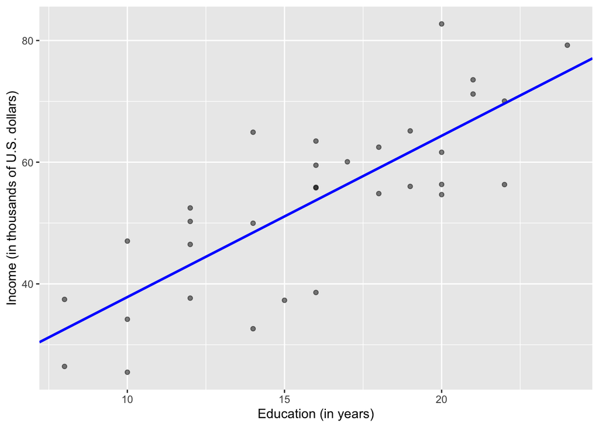

```r
betas <- coef(mdl)
intercept <- betas[1]
slope <- betas[2]
ggplot(data = riverview, aes(x = education, y = income)) +
  geom_point(alpha = 0.5) +
  geom_abline(intercept = intercept, slope = slope,
              color = 'blue', size = 1) +
  labs(x = "Education (in years)",
       y = "Income (in thousands of U.S. dollars)")
```

## Question 9

```r
riverview_fitted <- riverview %>%
  mutate(
    income_hat = predict(mdl),
    resid = income - income_hat
  )
head(riverview_fitted)
```

```
## # A tibble: 6 x 8
##   education income seniority gender  male party       income_hat  resid
##       <dbl>  <dbl>     <dbl> <chr>  <dbl> <chr>            <dbl>  <dbl>
## 1         8   37.4         7 male       1 Democrat          32.5   4.92
## 2         8   26.4         9 female     0 Independent       32.5  -6.10
## 3        10   47.0        14 male       1 Democrat          37.8   9.20
## 4        10   34.2        16 female     0 Independent       37.8  -3.65
## 5        10   25.5         1 female     0 Republican        37.8 -12.4
## 6        12   46.5        11 female     0 Democrat          43.1   3.35
```

- $y_{3}$ = response variable for unit $i = 3$ in the sample data
- $\hat y_{3}$ = fitted value for the third unit
- $\hat \epsilon_{5} = y_{5} - \hat y_{5}$ = the residual corresponding to the 5th unit.

## Question 10

Calculate the test statistic:
$$t = \frac{\hat \beta_1 - 0}{SE(\hat \beta_1)} = \frac{ 2.6513 - 0 }{0.3696} = 7.173$$

Compare it with the 5% critical value from a t-distribution with $n-2$ degrees of freedom, which is:

```r
n <- nrow(riverview)
tstar <- qt(0.975, df = n - 2)
tstar
```

```
## [1] 2.042272
```

As $|t|$ is much larger than $t^*$, we reject then null hypothesis as have strong evidence against it.

The p-value, shown below, also confirms the conclusion:

```r
2 * (1 - pt(7.173, n - 2))
```

```
## [1] 5.561692e-08
```

The same information was already contained in the row corresponding to the variable “education” in the output of `summary(mdl)`, which reported the t-statistic under `t value` and the p-value under `Pr(>|t|)`:

```r
summary(mdl)
```

```
##
## Call:
## lm(formula = income ~ 1 + education, data = riverview)
##
## Residuals:
##     Min      1Q  Median      3Q     Max
## -15.809  -5.783   2.088   5.127  18.379
##
## Coefficients:
##             Estimate Std. Error t value Pr(>|t|)
## (Intercept)  11.3214     6.1232   1.849   0.0743 .
## education     2.6513     0.3696   7.173 5.56e-08 ***
## ---
## Signif. codes:  0 '***' 0.001 '**' 0.01 '*' 0.05 '.' 0.1 ' ' 1
##
## Residual standard error: 8.978 on 30 degrees of freedom
## Multiple R-squared:  0.6317, Adjusted R-squared:  0.6194
## F-statistic: 51.45 on 1 and 30 DF,  p-value: 5.562e-08
```

We might report this as:

We performed a t-test against the null hypothesis that education is not a significant predictor of income: $t(30) = 7.173,\ p < .001$, two-sided. The large t-statistic leads to a very small p-value, meaning that we have strong evidence against the null hypothesis.

## Question 11

In the riverview example, for 95% confidence we have $t^* = 2.04$:

```r
n <- nrow(riverview)
tstar <- qt(0.975, df = n - 2)
tstar
```

```
## [1] 2.042272
```

The confidence interval is:

```r
beta1_ci <- tibble(
  lower = 2.6513 - tstar * 0.3696,
  upper = 2.6513 + tstar * 0.3696,
)
beta1_ci
```

```
## # A tibble: 1 x 2
##   lower upper
##   <dbl> <dbl>
## 1  1.90  3.41
```

In R it is easy to obtain the confidence intervals for the regression coefficients using the command `confint()`:

```r
confint(mdl, level = 0.95)
```

```
##                 2.5 %    97.5 %
## (Intercept) -1.183935 23.826693
## education    1.896425  3.406168
```

The result is exactly the same (up to rounding errors) as the previous one.

CI for slope:

For all Riverview city employees, each one-year difference in formal education is associated with a difference in income between $1,896 and $3,406, on average.

## Question 12

```r
riverview_fitted <- riverview %>%
  mutate(
    income_hat = predict(mdl),
    resid = income - income_hat
  )
head(riverview_fitted)
```

```
## # A tibble: 6 x 8
##   education income seniority gender  male party       income_hat  resid
##       <dbl>  <dbl>     <dbl> <chr>  <dbl> <chr>            <dbl>  <dbl>
## 1         8   37.4         7 male       1 Democrat          32.5   4.92
## 2         8   26.4         9 female     0 Independent       32.5  -6.10
## 3        10   47.0        14 male       1 Democrat          37.8   9.20
## 4        10   34.2        16 female     0 Independent       37.8  -3.65
## 5        10   25.5         1 female     0 Republican        37.8 -12.4
## 6        12   46.5        11 female     0 Democrat          43.1   3.35
```

```r
riverview_fitted %>%
  summarise(
    SSModel = sum( (income_hat - mean(income))^2 ),
    SSTotal = sum( (income - mean(income))^2 ),
    RSquared = SSModel / SSTotal
  )
```

```
## # A tibble: 1 x 3
##   SSModel SSTotal RSquared
##     <dbl>   <dbl>    <dbl>
## 1   4147.   6566.    0.632
```

Approximately 63% of the total variability in employee incomes is explained by the linear association with education level.

## Question 13

```r
df1 <- 1
df2 <- nrow(riverview) - 2
f_star <- qf(0.95, df1, df2)
f_star
```

```
## [1] 4.170877
```

```r
model_utility <- riverview_fitted %>%
  summarise(
    SSModel = sum( (income_hat - mean(income))^2 ),
    SSResid = sum( resid^2 ),
    MSModel = SSModel / 1,
    MSResid = SSResid / df2,
    FObs = MSModel / MSResid
  )
model_utility
```

```
## # A tibble: 1 x 5
##   SSModel SSResid MSModel MSResid  FObs
##     <dbl>   <dbl>   <dbl>   <dbl> <dbl>
## 1   4147.   2418.   4147.    80.6  51.5
```

We performed an F-test of model utility at the 5% significance level, where $F(1,30) = 51.45$.

As the observed $F = 51.45$ is much larger than the critical value $F^* = 4.17$, we have strong evidence to reject the null hypothesis that the model is ineffective.

Alternatively, we can compute the p-value:

```r
pvalue <- 1 - pf(model_utility$FObs, df1, df2)
pvalue
```

```
## [1] 5.562116e-08
```

We performed an F-test of model utility at the 5% significance level, where $F(1,30) = 51.45, p<.001$.

The p-value (< .001) is much lower than the specified significance level, meaning that we have very strong evidence against the null hypothesis.

## Question 14

Notes: I write in monospaced font by wrapping the sentence with backticks: this is an `example`.

```r
summary(mdl)
```

```
##
## Call:
## lm(formula = income ~ 1 + education, data = riverview)
##
## Residuals:
##     Min      1Q  Median      3Q     Max
## -15.809  -5.783   2.088   5.127  18.379
##
## Coefficients:
##             Estimate Std. Error t value Pr(>|t|)
## (Intercept)  11.3214     6.1232   1.849   0.0743 .
## education     2.6513     0.3696   7.173 5.56e-08 ***
## ---
## Signif. codes:  0 '***' 0.001 '**' 0.01 '*' 0.05 '.' 0.1 ' ' 1
##
## Residual standard error: 8.978 on 30 degrees of freedom
## Multiple R-squared:  0.6317, Adjusted R-squared:  0.6194
## F-statistic: 51.45 on 1 and 30 DF,  p-value: 5.562e-08
```

The relevant row is the following:

`F-statistic: 51.45 on 1 and 30 DF, p-value: 5.562e-08`

```r
anova(mdl)
```

```
## Analysis of Variance Table
##
## Response: income
##           Df Sum Sq Mean Sq F value    Pr(>F)
## education  1 4147.3  4147.3  51.452 5.562e-08 ***
## Residuals 30 2418.2    80.6
## ---
## Signif. codes:  0 '***' 0.001 '**' 0.01 '*' 0.05 '.' 0.1 ' ' 1
```

The relevant entries are:

- the `Df` column, which contains the degrees of freedom;
- `F value = 51.452`, which is the F-statistic;
- `Pr(>F) = 5.562e-08` = $5.562 \times 10^{-8}$, which is the p-value.

We performed an F-test for the overall significance of the regression, $F(1, 30) = 51.45, p < .001$. The large F-statistic leads to a very small p-value ($<.001$), meaning that we have very strong evidence against the null hypothesis that the model is ineffective.

In other words, the data provide strong evidence that education is an effective predictor of income.

## Question 15

```r
51.452
```

```
## [1] 51.452
```

```r
7.173^2
```

```
## [1] 51.45193
```

The squared t-statistic is equal, up to rounding error, to the F-statistic.

# Extra notes

What if I want to write a sentence that uses a calculated value from a previous code chunk? You do that by writing backtick, r, space, the calculated value, and close backtick.

The observed F statistic for testing model utility was 51.452. The code will be replaced by the numerical value when you knit the document, so the sentence will be a proper sentence with a number rather than code.